# GBM Analysis

2022-10-26

## Importing csv file

Data was first imported, and names were cleaned. As there was no data dictionary provided, the assumption was made that inputs of 999 and 9 indicated missing information. Therefore, all inputs of 999 and 9 were converted into NA using `replace_with_na_all`.

```r
gbm_data = read_csv(
  'data/gbm_patient_data.csv') %>%
  janitor::clean_names() %>%
  replace_with_na_all(condition = ~.x == 999) %>%
  replace_with_na_all(condition = ~.x == 9)
```

```
## ──────────────────────────────────────────────────────── Delimiter: "," chr
## (11): COUNTRY, Gender, Race, Patient's level of involvement in GBM, Pati... dbl
## (31): MD_ID, PATIENT_ID, Line of therapy, Year of birth, Age at diagnosi...
```

```r
skimr::skim(gbm_data)
```

Data summary

| Name | gbm_data |
| --- | --- |
| Number of rows | 750 |
| Number of columns | 42 |
| _______________________ |  |
| Column type frequency: |  |
| character | 11 |
| numeric | 31 |
| ________________________ |  |
| Group variables | None |

**Variable type: character**

| skim_variable | n_missing | complete_rate | min | max | empty | n_unique | whitespace |
| --- | --- | --- | --- | --- | --- | --- | --- |
| country | 0 | 1.00 | 2 | 2 | 0 | 1 | 0 |
| gender | 0 | 1.00 | 4 | 6 | 0 | 2 | 0 |
| race | 0 | 1.00 | 5 | 23 | 0 | 5 | 0 |
| patients_level_of_involvement_in_gbm | 0 | 1.00 | 36 | 44 | 0 | 3 | 0 |
| patients_treatment_goals | 0 | 1.00 | 24 | 31 | 0 | 2 | 0 |
| primary_insurance | 45 | 0.94 | 3 | 19 | 0 | 8 | 0 |
| comorbidity_other_specify_29 | 742 | 0.01 | 5 | 48 | 0 | 8 | 0 |
| regimen_in_1st_line | 0 | 1.00 | 5 | 20 | 0 | 8 | 0 |
| regimen_in_1st_line_other | 748 | 0.00 | 9 | 10 | 0 | 2 | 0 |
| regimen_in_2nd_line | 300 | 0.60 | 5 | 20 | 0 | 8 | 0 |
| regimen_in_2nd_line_other | 748 | 0.00 | 11 | 27 | 0 | 2 | 0 |

**Variable type: numeric**

| skim_variable | n_missing | complete_rate | mean | sd | p0 | p25 | p50 | p75 | p100 | hist |
| --- | --- | --- | --- | --- | --- | --- | --- | --- | --- | --- |
| md_id | 0 | 1.00 | 12604.37 | 1128.96 | 10487 | 11439.0 | 13266.0 | 13462.00 | 13536 | ▂▁▁▁▇ |
| patient_id | 0 | 1.00 | 126046.73 | 11289.60 | 104871 | 114393.2 | 132663.0 | 134622.75 | 135365 | ▂▁▁▁▇ |
| line_of_therapy | 0 | 1.00 | 1.60 | 0.49 | 1 | 1.0 | 2.0 | 2.00 | 2 | ▅▁▁▁▇ |
| year_of_birth | 0 | 1.00 | 1957.90 | 12.03 | 1925 | 1950.0 | 1957.0 | 1966.00 | 1996 | ▁▆▇▃▁ |
| age_at_diagnosis | 0 | 1.00 | 56.90 | 12.23 | 19 | 48.0 | 57.0 | 65.75 | 88 | ▁▃▇▆▂ |
| adequate_caretaker_support | 49 | 0.93 | 0.70 | 0.46 | 0 | 0.0 | 1.0 | 1.00 | 1 | ▃▁▁▁▇ |
| travel_time_to_your_office_30_min | 46 | 0.94 | 0.42 | 0.49 | 0 | 0.0 | 0.0 | 1.00 | 1 | ▇▁▁▁▆ |
| comorbidity_renal_impairment | 0 | 1.00 | 0.11 | 0.31 | 0 | 0.0 | 0.0 | 0.00 | 1 | ▇▁▁▁▁ |
| comorbidity_anemia | 0 | 1.00 | 0.16 | 0.36 | 0 | 0.0 | 0.0 | 0.00 | 1 | ▇▁▁▁▂ |
| comorbidity_copd_pulmonary | 0 | 1.00 | 0.11 | 0.32 | 0 | 0.0 | 0.0 | 0.00 | 1 | ▇▁▁▁▁ |
| comorbidity_diabetes | 0 | 1.00 | 0.18 | 0.39 | 0 | 0.0 | 0.0 | 0.00 | 1 | ▇▁▁▁▂ |
| comorbidity_chf_cong_heart_failure | 0 | 1.00 | 0.06 | 0.23 | 0 | 0.0 | 0.0 | 0.00 | 1 | ▇▁▁▁▁ |
| comorbidity_neuropathies | 0 | 1.00 | 0.06 | 0.24 | 0 | 0.0 | 0.0 | 0.00 | 1 | ▇▁▁▁▁ |
| comorbidity_other_neurological | 0 | 1.00 | 0.02 | 0.15 | 0 | 0.0 | 0.0 | 0.00 | 1 | ▇▁▁▁▁ |
| comorbidity_hepatic_insufficiency | 0 | 1.00 | 0.03 | 0.16 | 0 | 0.0 | 0.0 | 0.00 | 1 | ▇▁▁▁▁ |
| comorbidity_other_cytopenia | 0 | 1.00 | 0.03 | 0.17 | 0 | 0.0 | 0.0 | 0.00 | 1 | ▇▁▁▁▁ |
| comorbidity_autoimmune_disorder | 0 | 1.00 | 0.02 | 0.15 | 0 | 0.0 | 0.0 | 0.00 | 1 | ▇▁▁▁▁ |
| comorbidity_hypertension | 0 | 1.00 | 0.24 | 0.43 | 0 | 0.0 | 0.0 | 0.00 | 1 | ▇▁▁▁▂ |
| comorbidity_other_cardiovascular | 0 | 1.00 | 0.06 | 0.24 | 0 | 0.0 | 0.0 | 0.00 | 1 | ▇▁▁▁▁ |
| comorbidity_alzheimers | 0 | 1.00 | 0.01 | 0.11 | 0 | 0.0 | 0.0 | 0.00 | 1 | ▇▁▁▁▁ |
| comorbidity_other_cancer_besides_gbm | 0 | 1.00 | 0.02 | 0.13 | 0 | 0.0 | 0.0 | 0.00 | 1 | ▇▁▁▁▁ |
| comorbidity_other_specify_28 | 0 | 1.00 | 0.02 | 0.13 | 0 | 0.0 | 0.0 | 0.00 | 1 | ▇▁▁▁▁ |
| comorbidity_none | 0 | 1.00 | 0.47 | 0.50 | 0 | 0.0 | 0.0 | 1.00 | 1 | ▇▁▁▁▇ |
| ecog_at_1st_line | 0 | 1.00 | 1.28 | 1.14 | 0 | 1.0 | 1.0 | 2.00 | 4 | ▃▇▂▁▂ |
| ecog_at_2nd_line | 300 | 0.60 | 1.46 | 0.92 | 0 | 1.0 | 1.0 | 2.00 | 4 | ▃▇▇▂▁ |
| mgmt_methylated | 259 | 0.65 | 0.43 | 0.50 | 0 | 0.0 | 0.0 | 1.00 | 1 | ▇▁▁▁▆ |
| egfr_mutated | 386 | 0.49 | 0.45 | 0.50 | 0 | 0.0 | 0.0 | 1.00 | 1 | ▇▁▁▁▆ |
| tp53_mutated | 442 | 0.41 | 0.41 | 0.49 | 0 | 0.0 | 0.0 | 1.00 | 1 | ▇▁▁▁▆ |
| idh1_idh2_mutated | 486 | 0.35 | 0.34 | 0.48 | 0 | 0.0 | 0.0 | 1.00 | 1 | ▇▁▁▁▅ |
| pd_l1_overexpressed | 482 | 0.36 | 0.40 | 0.49 | 0 | 0.0 | 0.0 | 1.00 | 1 | ▇▁▁▁▅ |
| percent_of_tumor_mass_surgically_resected | 204 | 0.73 | 70.10 | 24.28 | 10 | 47.0 | 77.5 | 90.00 | 100 | ▁▃▃▃▇ |

## Exploratory data analysis

Initial exploratory data analysis was first conducted to gain a better grasp on the demographics of the patient population

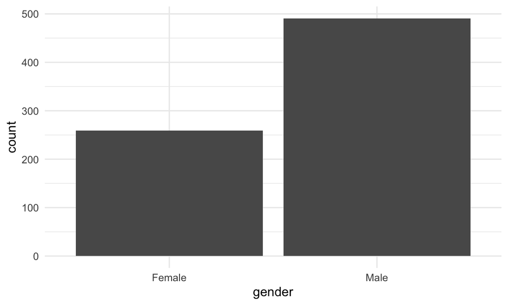

```r
ggplot(data = gbm_data, aes(x = gender), color = gender) + geom_bar()
```

```r
  gbm_data %>%
  group_by(gender) %>%
  summarise(n_obs = n())
```

```
## # A tibble: 2 × 2
##   gender n_obs
##   <chr>  <int>
## 1 Female   259
## 2 Male     491
```

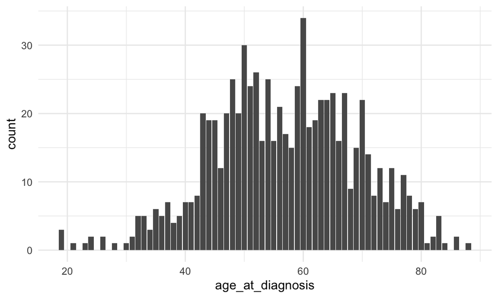

```r
ggplot(data = gbm_data, aes(x = age_at_diagnosis)) + geom_bar()
```

```r
  gbm_data %>%
  summarise(mean(age_at_diagnosis), median(age_at_diagnosis))
```

```
## # A tibble: 1 × 2
##   `mean(age_at_diagnosis)` `median(age_at_diagnosis)`
##                      <dbl>                      <dbl>
## 1                     56.9                         57
```

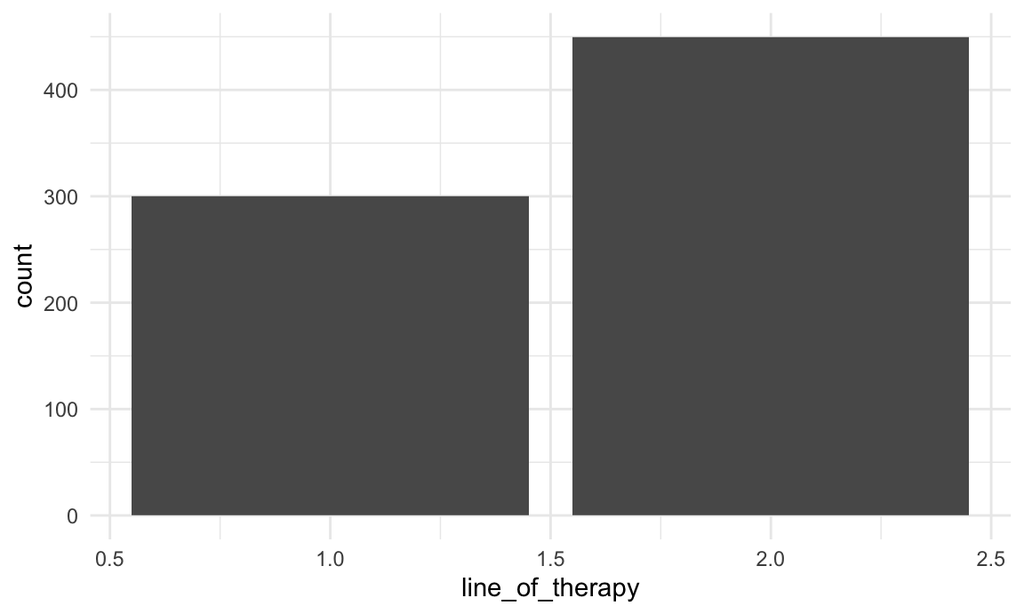

```r
ggplot(data = gbm_data, aes(x = line_of_therapy)) + geom_bar()
```

```r
  gbm_data %>%
  group_by(line_of_therapy) %>%
  summarise(n_obs = n())
```

```
## # A tibble: 2 × 2
##   line_of_therapy n_obs
##             <dbl> <int>
## 1               1   300
## 2               2   450
```

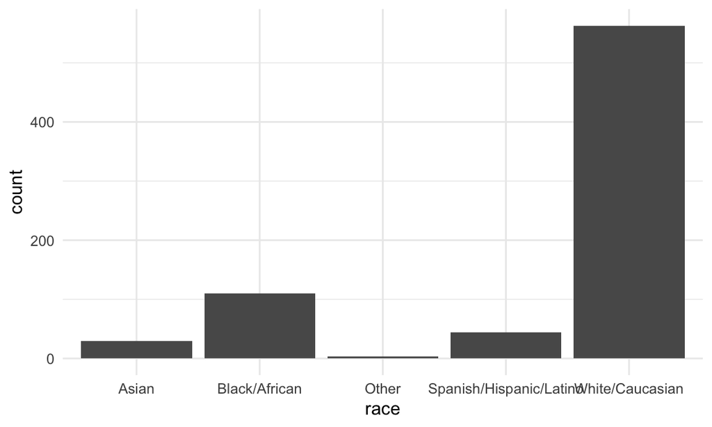

```r
ggplot(data = gbm_data, aes(x = race)) + geom_bar()
```

```r
  gbm_data %>%
  group_by(race) %>%
    summarise(n_obs = n())
```

```
## # A tibble: 5 × 2
##   race                    n_obs
##   <chr>                   <int>
## 1 Asian                      30
## 2 Black/African             110
## 3 Other                       3
## 4 Spanish/Hispanic/Latino    44
## 5 White/Caucasian           563
```

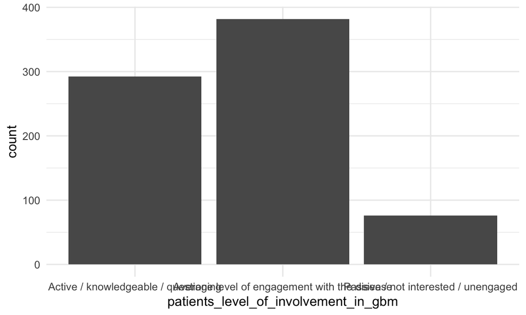

```r
ggplot(data = gbm_data, aes(x = patients_level_of_involvement_in_gbm)) + geom_bar()
```

```r
  gbm_data %>%
    group_by(patients_level_of_involvement_in_gbm) %>%
    summarise(n_obs = n())
```

```
## # A tibble: 3 × 2
##   patients_level_of_involvement_in_gbm         n_obs
##   <chr>                                        <int>
## 1 Active / knowledgeable / questioning           292
## 2 Average level of engagement with the disease   382
## 3 Passive / not interested / unengaged            76
```

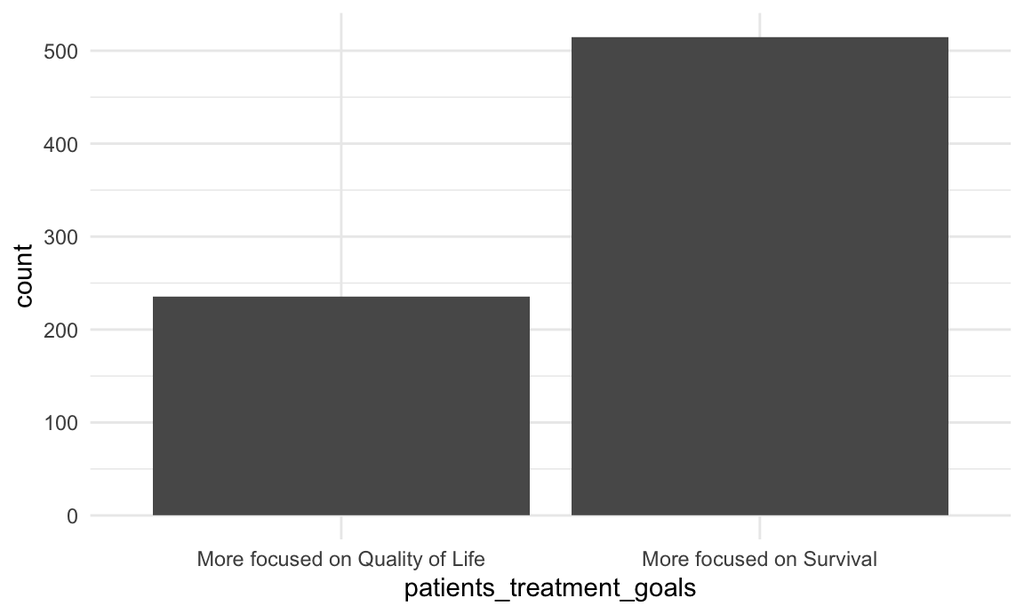

```r
ggplot(data = gbm_data, aes(x = patients_treatment_goals)) + geom_bar()
```

```r
  gbm_data %>%
    group_by(patients_treatment_goals) %>%
    summarise(n_obs = n())
```

```
## # A tibble: 2 × 2
##   patients_treatment_goals        n_obs
##   <chr>                           <int>
## 1 More focused on Quality of Life   235
## 2 More focused on Survival          515
```

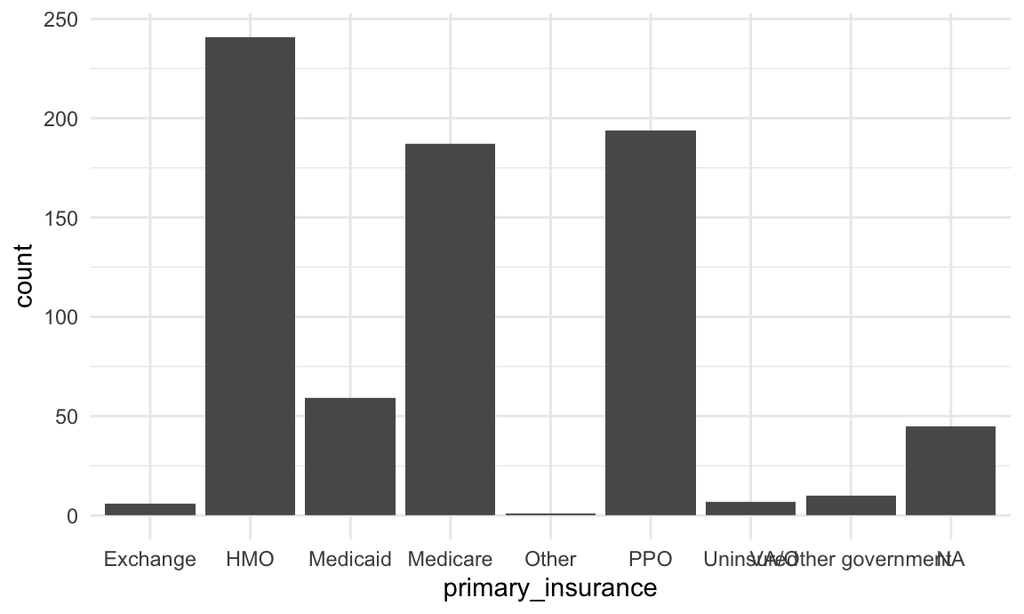

```r
ggplot(data = gbm_data, aes(x = primary_insurance)) + geom_bar()
```

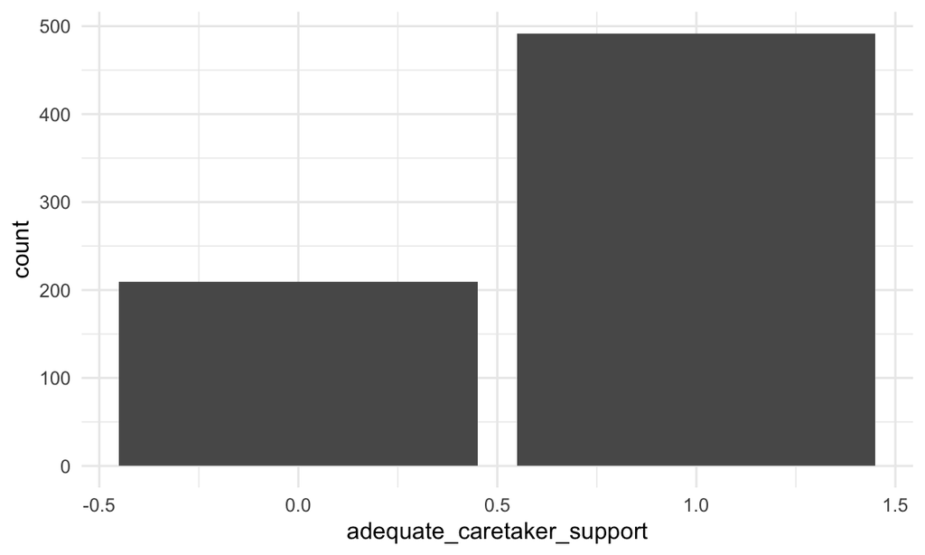

```r
ggplot(data = gbm_data, aes(x = adequate_caretaker_support)) + geom_bar()
```

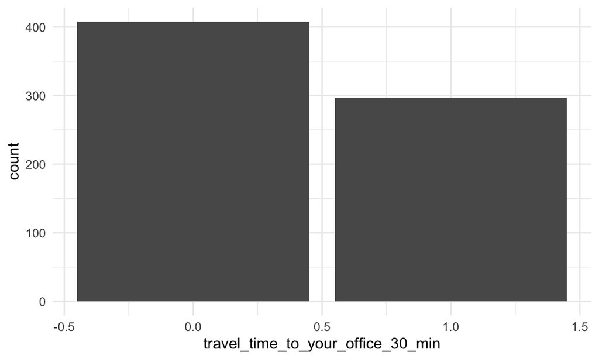

```r
ggplot(data = gbm_data, aes(x = travel_time_to_your_office_30_min)) + geom_bar()
```

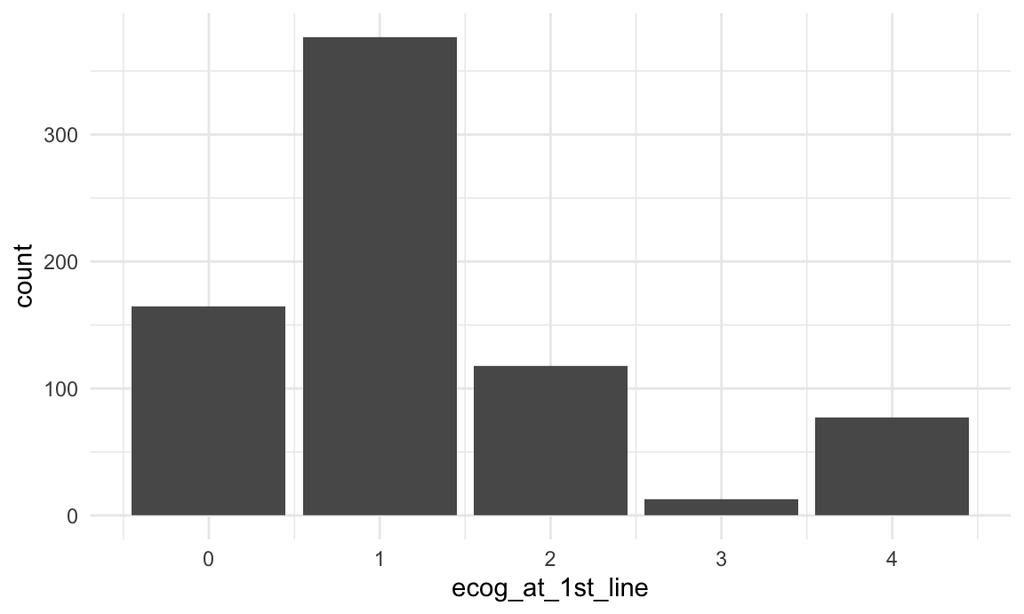

```r
ggplot(data = gbm_data, aes(x = ecog_at_1st_line)) + geom_bar()
```

```r
  gbm_data %>%
    summarise(mean(ecog_at_1st_line), sd(ecog_at_1st_line))
```

```
## # A tibble: 1 × 2
##   `mean(ecog_at_1st_line)` `sd(ecog_at_1st_line)`
##                      <dbl>                  <dbl>
## 1                     1.28                   1.14
```

```r
  gbm_data %>%
    group_by(ecog_at_1st_line) %>%
    summarise(n_obs = n())
```

```
## # A tibble: 5 × 2
##   ecog_at_1st_line n_obs
##              <dbl> <int>
## 1                0   165
## 2                1   377
## 3                2   118
## 4                3    13
## 5                4    77
```

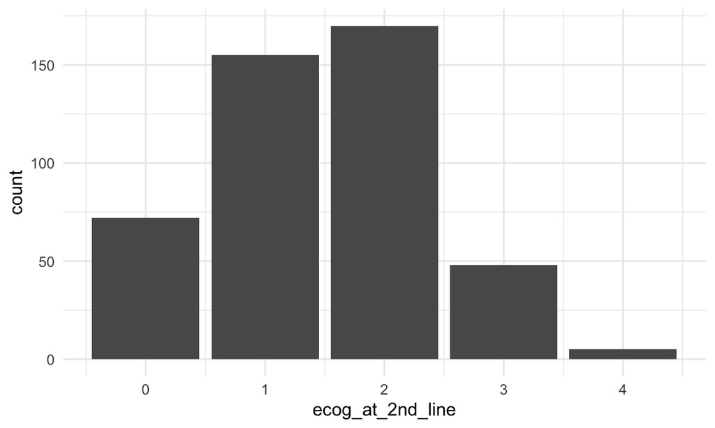

```r
ggplot(data = gbm_data, aes(x = ecog_at_2nd_line)) + geom_bar()
```

```r
  gbm_data %>%
    drop_na(ecog_at_2nd_line) %>%
    summarise(mean(ecog_at_2nd_line), sd(ecog_at_1st_line))
```

```
## # A tibble: 1 × 2
##   `mean(ecog_at_2nd_line)` `sd(ecog_at_1st_line)`
##                      <dbl>                  <dbl>
## 1                     1.46                   1.14
```

```r
  gbm_data %>%
    group_by(ecog_at_2nd_line) %>%
    summarise(n_obs = n())
```

```
## # A tibble: 6 × 2
##   ecog_at_2nd_line n_obs
##              <dbl> <int>
## 1                0    72
## 2                1   155
## 3                2   170
## 4                3    48
## 5                4     5
## 6               NA   300
```

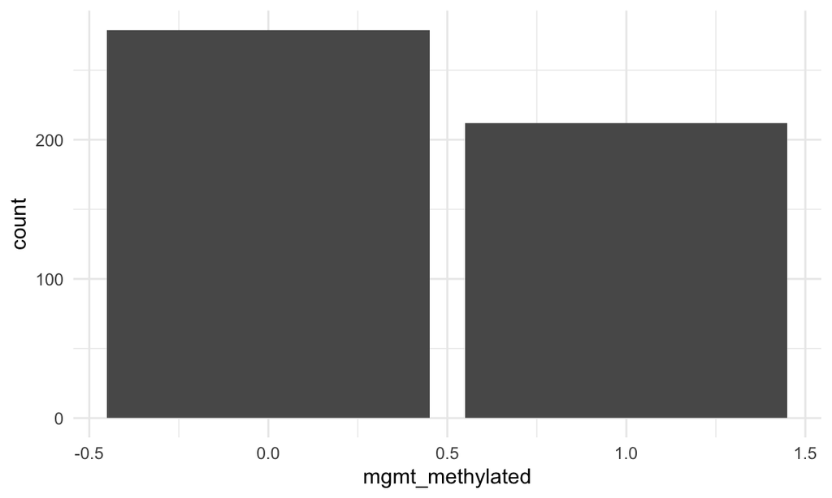

```r
ggplot(data = gbm_data, aes(x = mgmt_methylated)) + geom_bar()
```

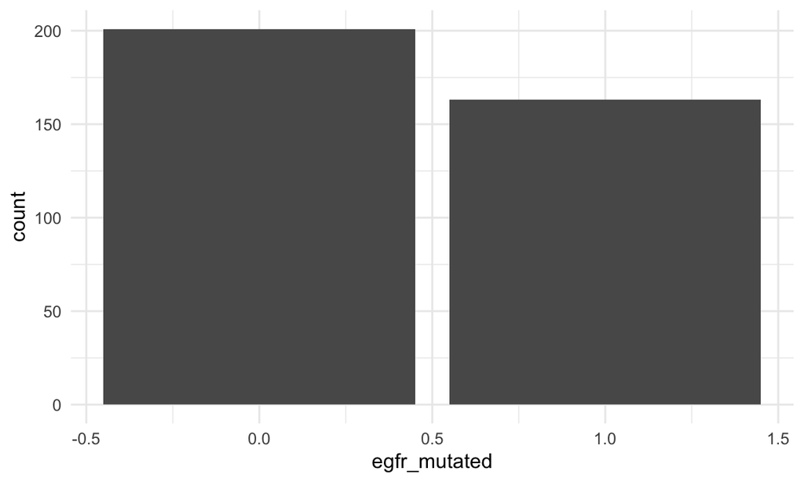

```r
ggplot(data = gbm_data, aes(x = egfr_mutated)) + geom_bar()
```

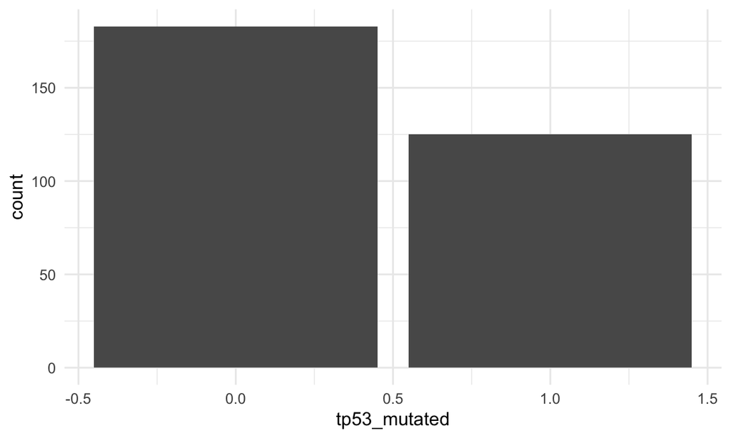

```r
ggplot(data = gbm_data, aes(x = tp53_mutated)) + geom_bar()
```

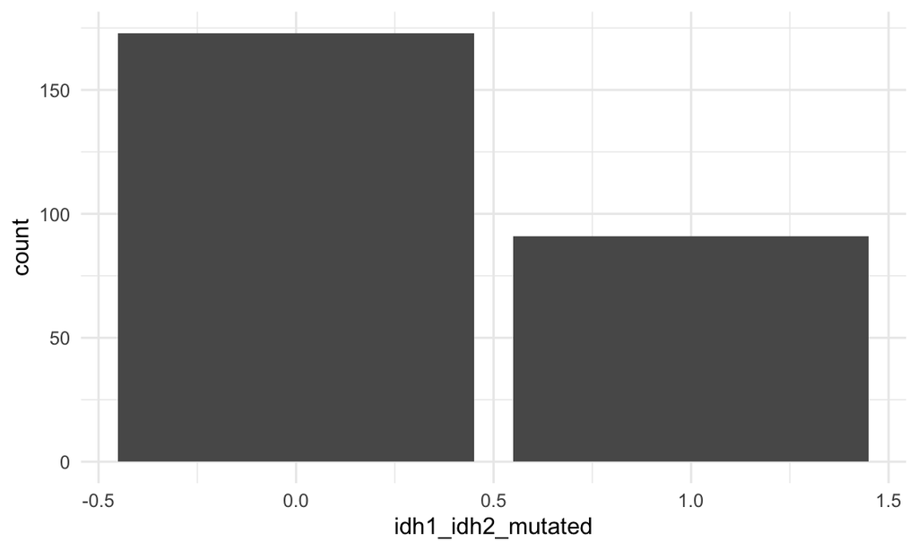

```r
ggplot(data = gbm_data, aes(x = idh1_idh2_mutated)) + geom_bar()
```

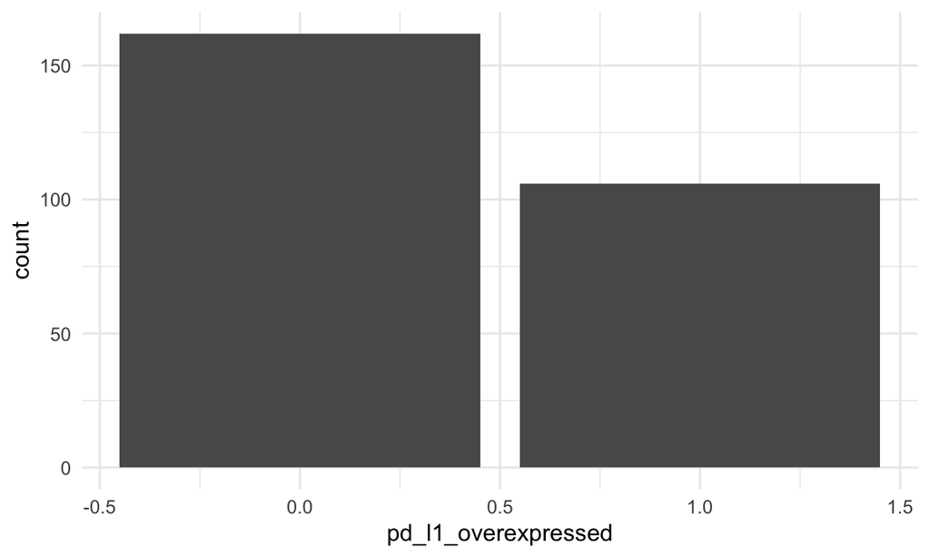

```r
ggplot(data = gbm_data, aes(x = pd_l1_overexpressed)) + geom_bar()
```

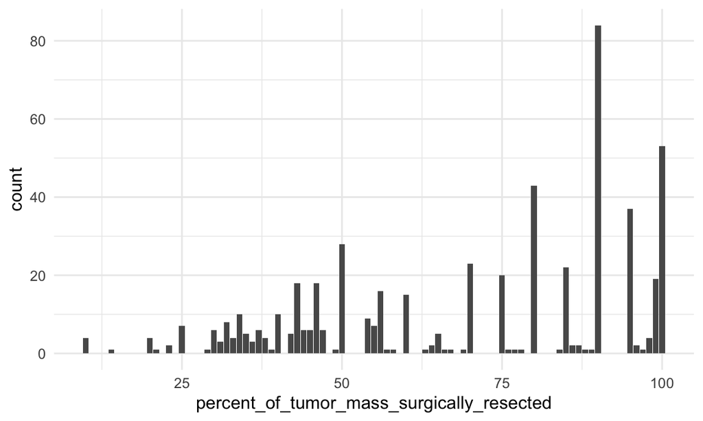

```r
ggplot(data = gbm_data, aes(x = percent_of_tumor_mass_surgically_resected)) + geom_bar()
```

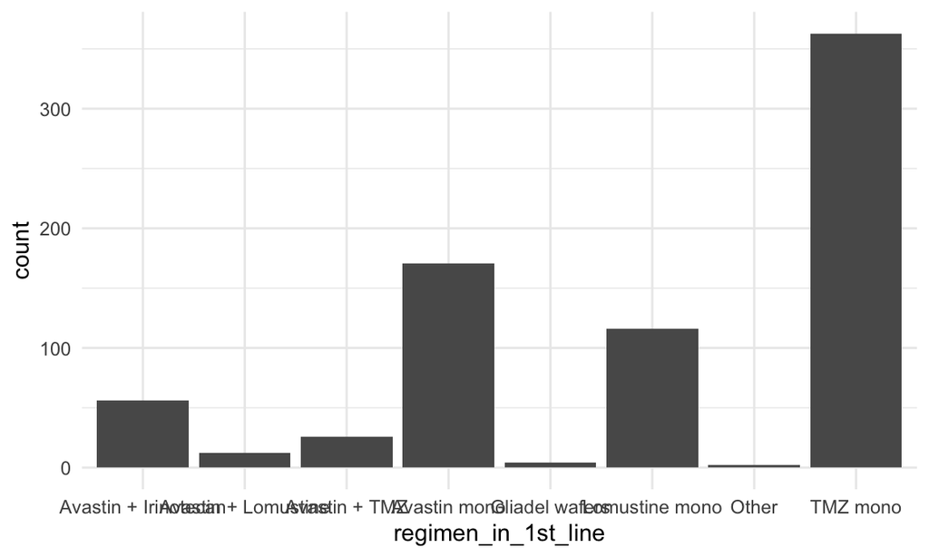

```r
ggplot(data = gbm_data, aes(x = regimen_in_1st_line)) + geom_bar()
```

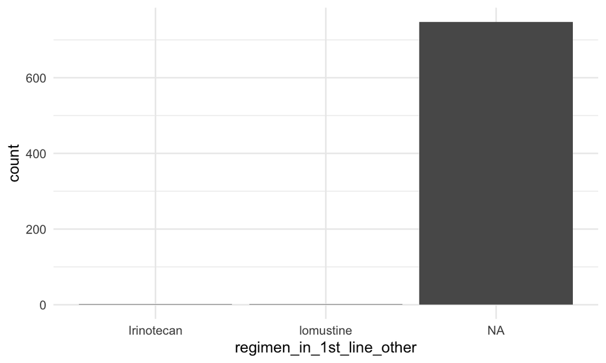

```r
ggplot(data = gbm_data, aes(x = regimen_in_1st_line_other)) + geom_bar()
```

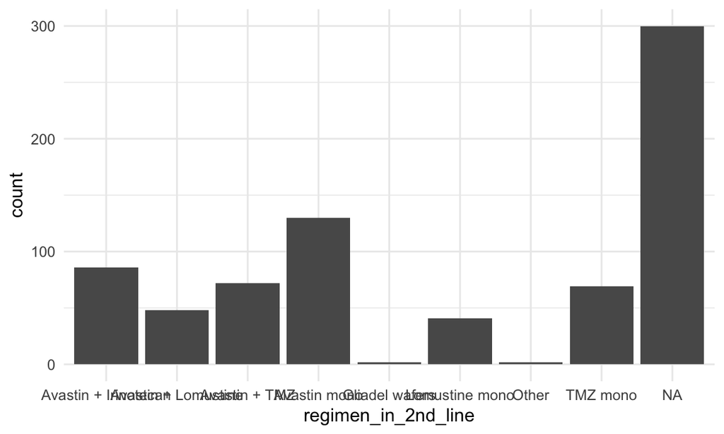

```r
ggplot(data = gbm_data, aes(x = regimen_in_2nd_line)) + geom_bar()
```

```r
  gbm_data %>%
    group_by(regimen_in_2nd_line) %>%
    summarise(n_obs = n())
```

```
## # A tibble: 9 × 2
##   regimen_in_2nd_line  n_obs
##   <chr>                <int>
## 1 Avastin + Irinotecan    86
## 2 Avastin + Lomustine     48
## 3 Avastin + TMZ           72
## 4 Avastin mono           130
## 5 Gliadel wafers           2
## 6 Lomustine mono          41
## 7 Other                    2
## 8 TMZ mono                69
## 9 <NA>                   300
```

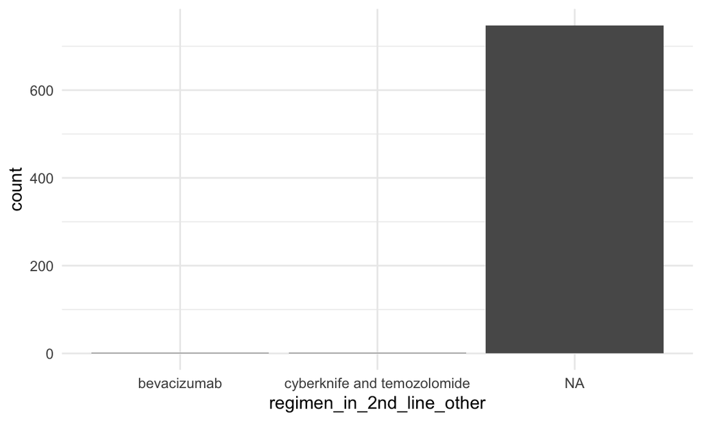

```r
ggplot(data = gbm_data, aes(x = regimen_in_2nd_line_other)) + geom_bar()
```

## Comorbidity analysis

Tidying dataframe: With a number of variables referring to patient comorbidity, a comorbidity dataframe was created based on the original dataset. The commorbidity dataframe pivoted and consolidated the comorbidity data, resulting in a variable `comorbidity_type` describing type of comorbidity and a second corresponding variable `comorbidity` with inputs of either 1 (yes) or 0 (no). The dataframe therefore consists of 3 variables: `patient_id`, `comorbidity_type`, and `comorbidity`.

```r
comorbidity_df = read_csv(
  'data/gbm_patient_data.csv') %>%
  janitor::clean_names() %>%
  mutate(
    age = 2022 - year_of_birth,
    ) %>%
  replace_with_na_all(condition = ~.x == 999) %>%
  replace_with_na_all(condition = ~.x == 9) %>%
  select(comorbidity_other_specify_29, everything()) %>%
  pivot_longer(
    comorbidity_renal_impairment:comorbidity_none,
    names_to = "comorbidity_type",
    names_prefix = "comorbidity_",
    values_to = "comorbidity",
  ) %>%
  select(patient_id, comorbidity_type, comorbidity)
```

```
## ──────────────────────────────────────────────────────── Delimiter: "," chr
## (11): COUNTRY, Gender, Race, Patient's level of involvement in GBM, Pati... dbl
## (31): MD_ID, PATIENT_ID, Line of therapy, Year of birth, Age at diagnosi...
```

Average number of comorbidities per patient

```r
comorbidity_df %>%
  group_by(patient_id) %>%
  filter(comorbidity_type != "none") %>%
  filter(comorbidity == 1) %>%
  mutate(n_obs = n()) %>%
  select(patient_id, n_obs) %>%
  distinct %>%
  ungroup(patient_id) %>%
  summarise(
            mean = mean(n_obs),
            sd = sd(n_obs)) %>%
  knitr::kable()
```

| mean | sd |
| --- | --- |
| 1.808511 | 1.197693 |

Distribution of number of comorbidities

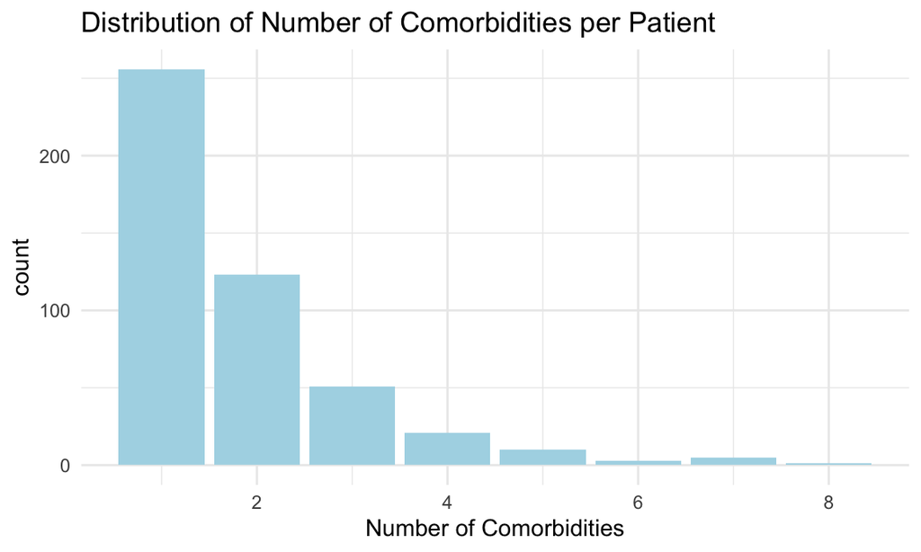

```r
comorbidity_df %>%
  group_by(patient_id) %>%
  filter(comorbidity_type != "none") %>%
  filter(comorbidity == 1) %>%
  mutate(n_obs = n()) %>%
  select(patient_id, n_obs) %>%
  distinct %>%
  ggplot(aes(x = n_obs)) +
  geom_bar(fill = "lightblue") +
  labs(
    title = "Distribution of Number of Comorbidities per Patient",
    x = "Number of Comorbidities")
```

```r
ggsave(path = "results", filename = "number_of_comorbidities.pdf")
```

Distribution of comorbidity types

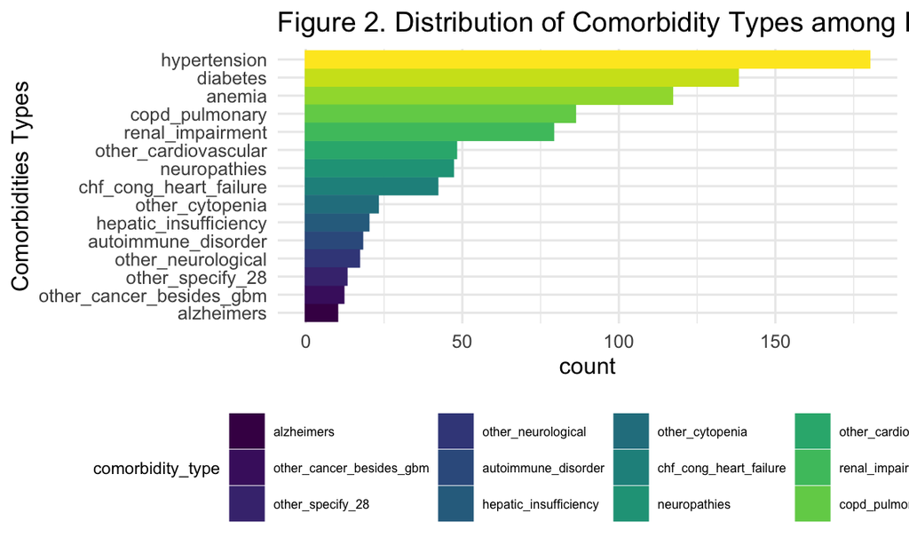

```r
comorbidity_df %>%
  filter(comorbidity_type != "none") %>%
  filter(comorbidity == 1) %>%
  group_by(comorbidity_type) %>%
  summarise(count = n()) %>%
  mutate(comorbidity_type = fct_reorder(comorbidity_type, count)) %>%
  ggplot(aes(x = comorbidity_type, y = count, color = comorbidity_type, fill = comorbidity_type)) +
  geom_bar(stat = "identity") +
  coord_flip() +
  labs(
    title = "Figure 2. Distribution of Comorbidity Types among Patients",
    x = "Comorbidities Types") +
    theme(legend.position = "bottom") +
    theme(legend.title = element_text(size = 8),
               legend.text = element_text(size = 6))
```

```r
ggsave(path = "results", filename = "distribution_of_comorbidity_types.pdf", width = 10, height = 7)
```

Comorbidity - other specified:

Only 8 patients specified other comorbidities. Specific comorbidities include: aortic aneurism, arthritis, bipolar, disc disease, elevated cholesterol, herniated disc surgery, obesity, and Parkinsons.

## ECOG Comparison

An ECOG dataframe was created to compare ECOG scores between 1st and 2nd line treatment. The dataframe consists of variables `patient_id`, `ecog_at_1st_line`, and `ecog_at_2nd_line`

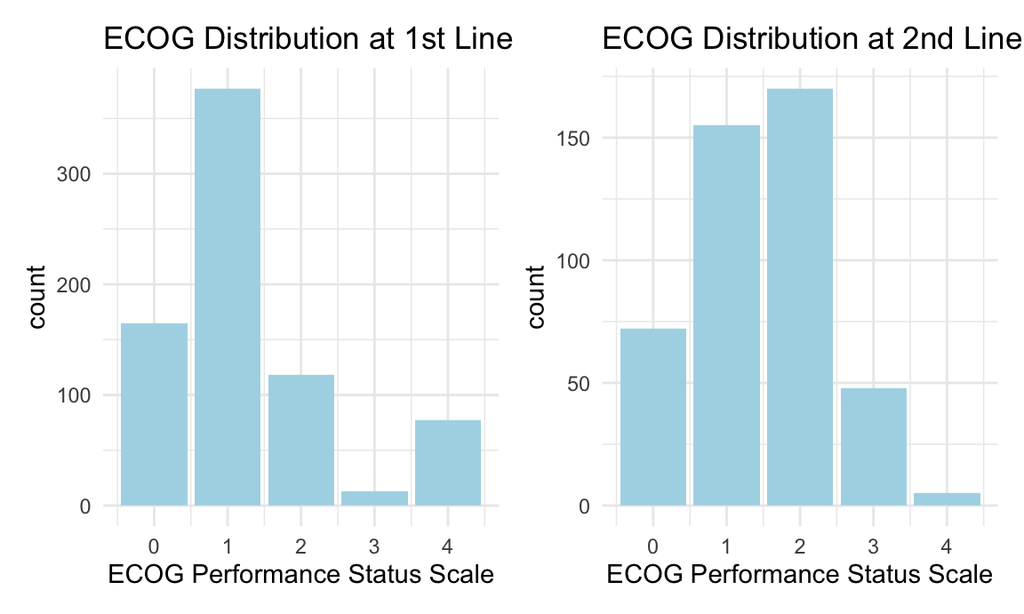

```r
ecog_data =
  gbm_data %>%
  select(patient_id, ecog_at_1st_line, ecog_at_2nd_line)

ggplot(data = ecog_data, aes(x = ecog_at_1st_line)) +
  geom_bar(fill = "lightblue") +
  labs(
    title = "ECOG Distribution at 1st Line",
    x = "ECOG Performance Status Scale") +
    theme(legend.position = "bottom") +

ggplot(data = ecog_data, aes(x = ecog_at_2nd_line)) +
  geom_bar(fill = "lightblue") +
  labs(
    title = "ECOG Distribution at 2nd Line",
    x = "ECOG Performance Status Scale") +
    theme(legend.position = "bottom")
```

```r
ggsave(path = "results", filename = "ecog_1st_2nd_comparison.pdf")
```

1st Line ECOG and 2nd Line ECOG by Treatment

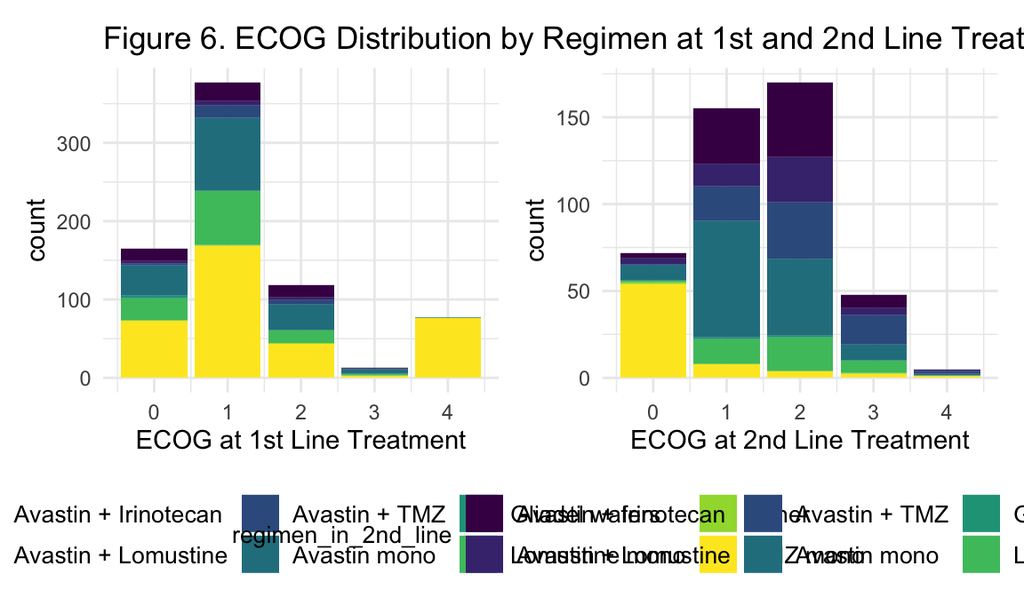

```r
ecog_data =
  gbm_data %>%
  select(patient_id, ecog_at_1st_line, ecog_at_2nd_line, regimen_in_1st_line, regimen_in_2nd_line)

ggplot(data = ecog_data, aes(x = ecog_at_1st_line, fill = regimen_in_1st_line)) +
  geom_bar() +
  labs(
    title = "Figure 6. ECOG Distribution by Regimen at 1st and 2nd Line Treatment",
    x = "ECOG at 1st Line Treatment") +
    theme(legend.position = "bottom") +
    theme(legend.title = element_text(size = 10),
               legend.text = element_text(size = 10)) +

  ggplot(data = ecog_data, aes(x = ecog_at_2nd_line, fill = regimen_in_2nd_line)) +
  geom_bar() +
  labs(
    x = "ECOG at 2nd Line Treatment") +
    theme(legend.position = "bottom") +
    theme(legend.title = element_text(size = 10),
               legend.text = element_text(size = 10))
```

```r
ggsave(path = "results", filename = "ecog_by_treatment_1st_2nd.pdf", width = 20, height = 12)
```

## Mutation Analysis

With a number of variablees referring to mutation type for each patient, a mutation dataframe was created to examine the types of mutations each patient indicated, as well as mutation distribution. The mutation dataframe was pivoted and consolidated mutation data, resulting in a variable `mutation_type` describing the type of mutation and a second corresponding variable `mutation` with inputs of either 1 (yes) or 0 (no). The dataframe therefore consists of 3 variables: `patient_id`, `mutation_type`, and `mutation`.

```r
mutation_df =
  gbm_data %>%
  select(patient_id, gender, mgmt_methylated:pd_l1_overexpressed, regimen_in_1st_line, regimen_in_2nd_line) %>%
  pivot_longer(
    mgmt_methylated:pd_l1_overexpressed,
    names_to = "mutation_type",
    values_to = "mutation"
  )
```

Average number of mutations per patient

```r
mutation_df %>%
  group_by(patient_id) %>%
  filter(mutation == 1) %>%
  mutate(n_obs = n()) %>%
  select(patient_id, n_obs) %>%
  distinct %>%
  ungroup(patient_id) %>%
  summarise(
            mean = mean(n_obs),
            sd = sd(n_obs)) %>%
  knitr::kable()
```

| mean | sd |
| --- | --- |
| 2.026163 | 1.351777 |

Distribution of number of mutations per patient

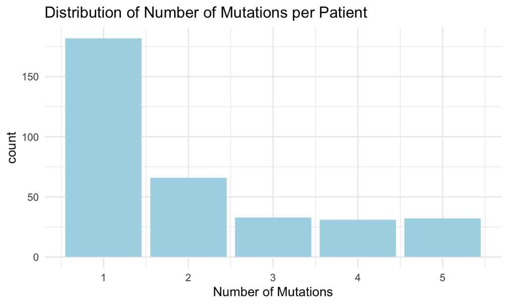

```r
mutation_df %>%
  group_by(patient_id) %>%
  filter(mutation == 1) %>%
  mutate(n_obs = n()) %>%
  select(patient_id, n_obs) %>%
  distinct %>%
  ggplot(aes(x = n_obs)) +
  geom_bar(fill = "lightblue") +
  labs(
    title = "Distribution of Number of Mutations per Patient",
    x = "Number of Mutations")
```

```r
mutation_df %>%
  group_by(mutation_type) %>%
  filter(mutation == 1) %>%
  summarise(n_obs = n())
```

```
## # A tibble: 5 × 2
##   mutation_type       n_obs
##   <chr>               <int>
## 1 egfr_mutated          163
## 2 idh1_idh2_mutated      91
## 3 mgmt_methylated       212
## 4 pd_l1_overexpressed   106
## 5 tp53_mutated          125
```

```r
ggsave(path = "results", filename = "number_of_mmutations.pdf")
```

Distribution of mutation type

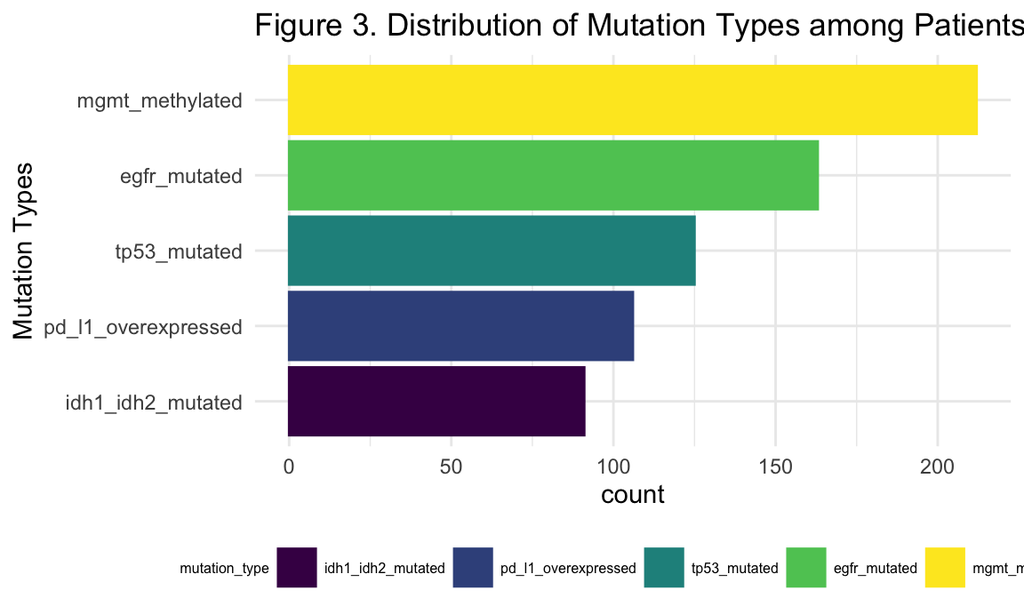

```r
mutation_df %>%
  filter(mutation == 1) %>%
  group_by(mutation_type) %>%
  summarise(count = n()) %>%
  mutate(mutation_type = fct_reorder(mutation_type, count)) %>%
  ggplot(aes(x = mutation_type, y = count, color = mutation_type, fill = mutation_type)) +
  geom_bar(stat = "identity") +
  coord_flip() +
  labs(
    title = "Figure 3. Distribution of Mutation Types among Patients",
    x = "Mutation Types") +
    theme(legend.position = "bottom")+
    theme(legend.title = element_text(size = 6),
               legend.text = element_text(size = 6))
```

```r
ggsave(path = "results", filename = "mutation_distribution.pdf")
```

Gender distribution across mutations

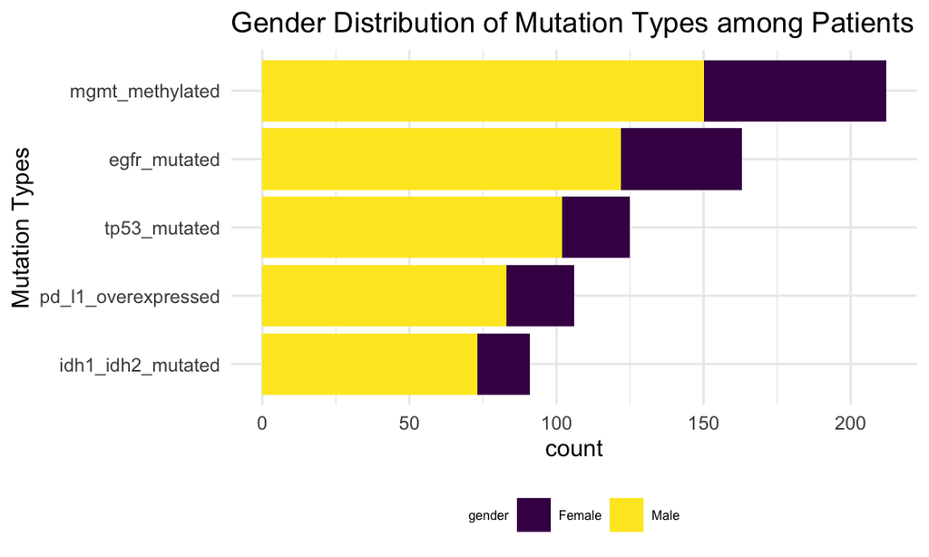

```r
mutation_gender_df =
  mutation_df %>%
    filter(mutation == 1) %>%
    group_by(patient_id) %>%
    mutate(count = n()) %>%
    mutate(mutation_type = fct_reorder(mutation_type, count))

ggplot(data = mutation_gender_df, (aes(x = reorder(mutation_type, -count), fill = gender))) +
  geom_bar() +
  coord_flip() +
  labs(
    title = "Gender Distribution of Mutation Types among Patients",
    x = "Mutation Types") +
    theme(legend.position = "bottom")+
    theme(legend.title = element_text(size = 6),
               legend.text = element_text(size = 6))
```

```r
ggsave(path = "results", filename = "mutation_gender_distribution.pdf")
```

1st ine treatment distribution across mutations

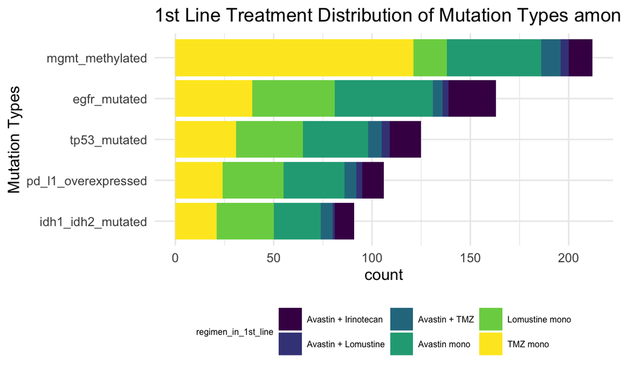

```r
mutation_1st_line_df =
  mutation_df %>%
  filter(mutation == 1) %>%
  group_by(patient_id) %>%
  mutate(count = n()) %>%
  mutate(mutation_type = fct_reorder(mutation_type, count))

ggplot(data = mutation_1st_line_df, (aes(x = reorder(mutation_type, -count), fill = regimen_in_1st_line))) +
  geom_bar() +
  coord_flip() +
  labs(
    title = "1st Line Treatment Distribution of Mutation Types among Patients",
    x = "Mutation Types") +
    theme(legend.position = "bottom")+
    theme(legend.title = element_text(size = 6),
               legend.text = element_text(size = 6))
```

```r
ggsave(path = "results", filename = "mutation_1st_line_distribution.pdf")
```

2nd line treatment distribution across mutations

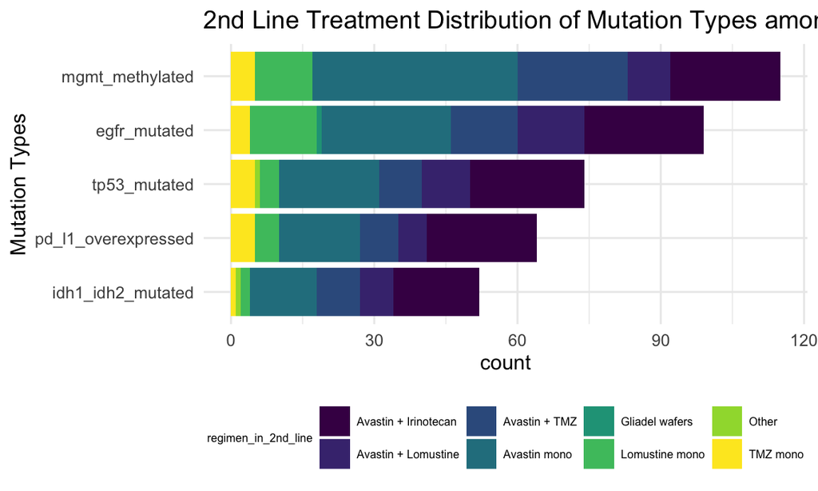

```r
mutation_2nd_line_df =
  mutation_df %>%
  drop_na(regimen_in_2nd_line) %>%
  filter(mutation == 1) %>%
  group_by(patient_id) %>%
  mutate(count = n()) %>%
  mutate(mutation_type = fct_reorder(mutation_type, count))

ggplot(data = mutation_2nd_line_df, (aes(x = reorder(mutation_type, -count), fill = regimen_in_2nd_line))) +
  geom_bar() +
  coord_flip() +
  labs(
    title = "2nd Line Treatment Distribution of Mutation Types among Patients",
    x = "Mutation Types") +
    theme(legend.position = "bottom")+
    theme(legend.title = element_text(size = 6),
               legend.text = element_text(size = 6))
```

```r
ggsave(path = "results", filename = "mutation_2nd_line_distribution.pdf")
```

Combining Graphs: 1st and 2nd line treatment distribution across mutations

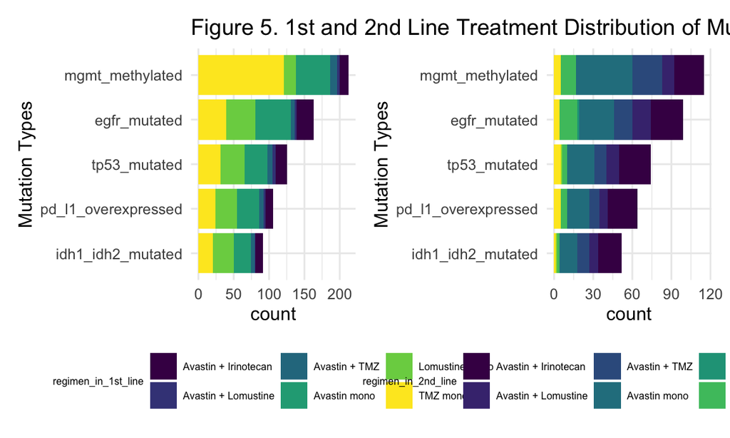

```r
ggplot(data = mutation_1st_line_df, (aes(x = reorder(mutation_type, -count), fill = regimen_in_1st_line))) +
  geom_bar() +
  coord_flip() +
  labs(
    title = "Figure 5. 1st and 2nd Line Treatment Distribution of Mutation Types among Patients",
    x = "Mutation Types") +
    theme(legend.position = "bottom")+
    theme(legend.title = element_text(size = 6),
               legend.text = element_text(size = 6)) +

ggplot(data = mutation_2nd_line_df, (aes(x = reorder(mutation_type, -count), fill = regimen_in_2nd_line))) +
  geom_bar() +
  coord_flip() +
  labs(
    x = "Mutation Types") +
    theme(legend.position = "bottom")+
    theme(legend.title = element_text(size = 6),
               legend.text = element_text(size = 6))
```

```r
ggsave(path = "results", filename = "mutation_1st_and_2nd_line_distribution.pdf", width = 14, height = 7)
```